# HBSC: Modeling

Updated: 2026-08-19

```r
rm(list = ls())

setwd("C:/MisLocalFiles/Github/HBSC/scripts/modeling/")
project_folder <- "C:/MisLocalFiles/Github/HBSC/"

require(tidyverse)
require(caret)
require(broom)
require(kableExtra)
library(knitr)
require(coefplot)
require(sjPlot)
require(shapviz)
require(xgboost)
```

# Data Overview

This data is prepared in hbsc.rmd file. It’s dimensions are:

```r
# ---------------------------------------------------------
# load dataset
# ---------------------------------------------------------

d <- read_csv(paste0(project_folder, "data/processed/dat_2026-08-16.csv"))

dim(d) #244097     25
```

```
[1] 244097     25
```

The list of vars and it’s type is:

```r
glimpse(d)
```

```
Rows: 244,097
Columns: 25
$ seqno_int            <dbl> 100001, 100002, 100004, 100005, 100007, 100008, 100009, 100010, 100011, 100012, 100013,…
$ country_name         <chr> "Albania", "Albania", "Albania", "Albania", "Albania", "Albania", "Albania", "Albania",…
$ lifesat_low          <dbl> 0, 0, 0, NA, 0, 0, NA, 1, NA, NA, 0, 0, 0, 0, 0, 0, 0, NA, 0, NA, 0, 0, 0, 0, 0, 0, 0, …
$ mental_complaintsY   <dbl> 1, 0, 0, 0, 1, 1, 0, NA, NA, 0, 0, NA, 0, 0, NA, 1, 0, NA, NA, 0, 1, 0, 0, 0, 0, 0, 1, …
$ health_complaintsY   <dbl> 1, 0, 0, 0, 1, 1, 0, NA, NA, 0, 0, NA, 0, 0, NA, 1, 0, NA, NA, 1, 1, 0, 0, 0, 0, 0, 1, …
$ pmsu_lmh             <chr> "Med", "Med", "High", "Med", "Med", "Low", "Med", "Low", "Low", NA, "Med", NA, "Low", "…
$ pmsu_yn              <dbl> 0, 0, 1, 0, 0, 0, 0, 0, 0, NA, 0, NA, 0, 0, NA, 0, 0, NA, 0, 0, 0, NA, 0, 0, 0, 0, 0, 0…
$ family_support_high  <dbl> 1, 1, 1, 1, 0, 1, 1, NA, 1, 1, NA, NA, 1, 1, 1, 1, 1, 0, 1, 1, 1, 1, 1, 1, 1, 1, 1, 1, …
$ family_support_hml   <chr> "High", "High", "High", "High", "Low", "High", "High", NA, "High", "High", NA, NA, "Hig…
$ friends_support_high <dbl> 1, 1, 0, 1, 0, 1, 1, 1, 1, 1, NA, 0, 1, 1, 1, 0, 1, NA, 1, 0, 1, 1, 0, 0, 0, 1, NA, 0, …
$ friends_support_hml  <chr> "High", "High", "Med", "High", "High", "High", "High", "High", "High", "High", NA, "Med…
$ teacher_support_high <dbl> 1, 1, 1, 1, 1, 1, 1, 1, 1, 1, 1, 1, 1, 1, 0, 0, 1, 1, 1, 1, 1, 0, 0, 1, 1, 1, 1, 1, 1, …
$ student_support_high <dbl> 1, 1, 1, 1, 0, 1, 1, 1, 0, 0, 1, 0, 1, 1, 0, 0, 1, 1, 1, 1, 1, 1, 1, 1, 1, 1, 1, 1, 1, …
$ school_support_high  <dbl> 1, 1, 1, 1, 1, 1, 1, 1, 1, 1, 1, 0, 1, 1, 0, 0, 1, 1, 1, 1, 1, 1, 0, 1, 1, 1, 1, 1, 1, …
$ IRRELFAS_LMH_r       <chr> "Med60", NA, NA, NA, NA, NA, NA, NA, NA, NA, NA, NA, "Med60", NA, "Med60", "Med60", "Me…
$ talkfatherYes        <dbl> 1, 1, 1, 1, 0, 0, 1, NA, NA, 1, NA, NA, 1, NA, 1, 1, 1, NA, 1, 0, 1, 1, 1, 1, 1, 1, 0, …
$ talkmotherYes        <dbl> 1, 1, 1, 1, 1, 1, 1, NA, NA, 1, NA, NA, 1, NA, NA, 1, 1, NA, NA, 0, 1, 1, 1, 1, 1, 1, 1…
$ beenbulliedYes       <dbl> 0, 1, 0, 1, 0, 0, 0, 0, 1, 1, 0, 1, 0, 0, 0, 1, 0, 1, 0, 1, 0, 0, 0, 0, 0, 0, 1, 0, 0, …
$ cbeenbulliedYes      <dbl> 1, 1, 1, 0, 0, 0, 0, 0, NA, 0, 0, 0, 0, NA, 0, 0, 0, 1, 0, 1, 0, 0, 0, 0, 0, 0, 0, 0, 0…
$ age_r                <dbl> NA, NA, NA, NA, NA, NA, NA, NA, NA, NA, NA, NA, NA, NA, NA, NA, NA, NA, NA, NA, NA, NA,…
$ sex_r                <chr> "Boy", "Boy", "Boy", "Boy", "Boy", "Boy", "Boy", "Boy", "Boy", "Boy", "Boy", "Boy", "Bo…
$ emconlfreqYes        <dbl> 0, 0, 1, 0, 1, 0, 0, 1, 1, 0, NA, 0, 0, 1, 0, 0, 1, 0, 0, 1, 1, 0, 1, 0, 0, 0, 1, 0, 1,…
$ lives_onlineYN       <dbl> 0, 1, 0, 0, 0, 0, NA, 0, 0, 0, NA, 1, 0, 0, 0, 0, 0, NA, 0, 0, 0, 0, 0, 0, 0, 0, 0, 0, …
$ timeexe_r            <dbl> 1, 1, 1, 1, 0, 0, 1, 1, 1, 0, 1, 1, 1, 1, 1, 0, 1, NA, 1, NA, 0, 1, 0, 1, 1, 1, 0, 1, 1…
$ alc30d_YN            <dbl> 0, 1, 0, 0, 0, 0, 0, 0, 0, 0, 0, 0, 0, 0, 0, 0, 0, NA, 0, 1, 0, 0, 0, NA, NA, 0, 1, NA,…
```

# Missing Values

Most features have missing values.

```r
summary(d)
```

```
   seqno_int       country_name        lifesat_low     mental_complaintsY health_complaintsY   pmsu_lmh
 Min.   : 100001   Length:244097      Min.   :0.0000   Min.   :0.0000     Min.   :0.0000     Length:244097
 1st Qu.:1013119   Class :character   1st Qu.:0.0000   1st Qu.:0.0000     1st Qu.:0.0000     Class :character
 Median :2301741   Mode  :character   Median :0.0000   Median :0.0000     Median :0.0000     Mode  :character
 Mean   :2390239                      Mean   :0.1327   Mean   :0.2774     Mean   :0.3667
 3rd Qu.:3600677                      3rd Qu.:0.0000   3rd Qu.:1.0000     3rd Qu.:1.0000
 Max.   :4813535                      Max.   :1.0000   Max.   :1.0000     Max.   :1.0000
                                      NA's   :4512     NA's   :12882      NA's   :14191
    pmsu_yn      family_support_high family_support_hml friends_support_high friends_support_hml teacher_support_high
 Min.   :0.000   Min.   :0.0000      Length:244097      Min.   :0.0000       Length:244097       Min.   :0.000
 1st Qu.:0.000   1st Qu.:0.0000      Class :character   1st Qu.:0.0000       Class :character    1st Qu.:0.000
 Median :0.000   Median :1.0000      Mode  :character   Median :1.0000       Mode  :character    Median :1.000
 Mean   :0.073   Mean   :0.7038                         Mean   :0.5856                           Mean   :0.553
 3rd Qu.:0.000   3rd Qu.:1.0000                         3rd Qu.:1.0000                           3rd Qu.:1.000
 Max.   :1.000   Max.   :1.0000                         Max.   :1.0000                           Max.   :1.000
 NA's   :50910   NA's   :22353                          NA's   :12896                            NA's   :19761
 student_support_high school_support_high IRRELFAS_LMH_r     talkfatherYes    talkmotherYes    beenbulliedYes
 Min.   :0.0000       Min.   :0.0000      Length:244097      Min.   :0.0000   Min.   :0.0000   Min.   :0.000
 1st Qu.:0.0000       1st Qu.:0.0000      Class :character   1st Qu.:0.0000   1st Qu.:1.0000   1st Qu.:0.000
 Median :1.0000       Median :0.0000      Mode  :character   Median :1.0000   Median :1.0000   Median :0.000
 Mean   :0.5708       Mean   :0.4955                         Mean   :0.6713   Mean   :0.8348   Mean   :0.268
 3rd Qu.:1.0000       3rd Qu.:1.0000                         3rd Qu.:1.0000   3rd Qu.:1.0000   3rd Qu.:1.000
 Max.   :1.0000       Max.   :1.0000                         Max.   :1.0000   Max.   :1.0000   Max.   :1.000
 NA's   :18798        NA's   :22626                          NA's   :17491    NA's   :15521    NA's   :16962
 cbeenbulliedYes      age_r          sex_r           emconlfreqYes    lives_onlineYN    timeexe_r
 Min.   :0.0000   Min.   :11.00   Length:244097      Min.   :0.0000   Min.   :0.000   Min.   :0.000
 1st Qu.:0.0000   1st Qu.:11.00   Class :character   1st Qu.:0.0000   1st Qu.:0.000   1st Qu.:0.000
 Median :0.0000   Median :13.00   Mode  :character   Median :0.0000   Median :0.000   Median :1.000
 Mean   :0.1315   Mean   :12.96                      Mean   :0.3428   Mean   :0.183   Mean   :0.711
 3rd Qu.:0.0000   3rd Qu.:15.00                      3rd Qu.:1.0000   3rd Qu.:0.000   3rd Qu.:1.000
 Max.   :1.0000   Max.   :15.00                      Max.   :1.0000   Max.   :1.000   Max.   :1.000
 NA's   :15084    NA's   :1516                       NA's   :25614    NA's   :31906   NA's   :4799
   alc30d_YN
 Min.   :0.0000
 1st Qu.:0.0000
 Median :0.0000
 Mean   :0.1904
 3rd Qu.:0.0000
 Max.   :1.0000
 NA's   :19326
```

For now, I will just keep complete observations to simplify my life. But as can be seen some countries are very afected. Netherlands is a good option.

```r
d <- d %>%
  mutate(any_na = if_any(everything(), is.na))

d %>%
  group_by(country_name, any_na) %>%
  tally() %>%
  pivot_wider(names_from = any_na,
              names_prefix = "na_",
              values_from = n,
              values_fill = 0) %>%
  mutate(n = na_FALSE + na_TRUE) %>%
  mutate(pct_complete = round(na_FALSE / n,3)) %>%
  select(n, na_FALSE, pct_complete) %>%
  arrange(desc(pct_complete))-> tbl_nas_country

kable(tbl_nas_country)
```

| country_name | n | na_FALSE | pct_complete |
| --- | --- | --- | --- |
| Netherlands | 4698 | 4248 | 0.904 |
| Portugal | 6126 | 5109 | 0.834 |
| Estonia | 4725 | 3864 | 0.818 |
| Lithuania | 3797 | 3066 | 0.807 |
| Italy | 4144 | 3314 | 0.800 |
| Hungary | 3789 | 2957 | 0.780 |
| Iceland | 6996 | 5395 | 0.771 |
| Spain | 4320 | 3209 | 0.743 |
| Slovenia | 5667 | 4161 | 0.734 |
| Czech Republic | 11564 | 8420 | 0.728 |
| Austria | 4129 | 3002 | 0.727 |
| Belgium (Flemish) | 4333 | 3145 | 0.726 |
| Romania | 4567 | 3264 | 0.715 |
| Germany | 4347 | 3102 | 0.714 |
| Scotland | 5021 | 3578 | 0.713 |
| Serbia | 3933 | 2738 | 0.696 |
| Republic of Moldova | 4686 | 3248 | 0.693 |
| Ukraine | 6660 | 4612 | 0.692 |
| England | 3397 | 2324 | 0.684 |
| Sweden | 4185 | 2814 | 0.672 |
| Ireland | 3833 | 2493 | 0.650 |
| France | 9170 | 5858 | 0.639 |
| Georgia | 4242 | 2694 | 0.635 |
| Belgium (French) | 5578 | 3537 | 0.634 |
| Albania | 1765 | 1115 | 0.632 |
| Russia | 4281 | 2675 | 0.625 |
| Luxembourg | 4070 | 2471 | 0.607 |
| Israel | 7712 | 4509 | 0.585 |
| Croatia | 5169 | 2985 | 0.577 |
| Canada | 12950 | 7423 | 0.573 |
| Finland | 3146 | 1737 | 0.552 |
| Wales | 15951 | 8613 | 0.540 |
| Kazakhstan | 4868 | 2328 | 0.478 |
| Armenia | 4717 | 2163 | 0.459 |
| Malta | 2576 | 1068 | 0.415 |
| Norway | 3127 | 1005 | 0.321 |
| Azerbaijan | 4586 | 0 | 0.000 |
| Denmark | 3181 | 0 | 0.000 |
| Greenland | 1243 | 0 | 0.000 |
| Latvia | 4412 | 0 | 0.000 |
| Macedonia | 4658 | 0 | 0.000 |
| Poland | 5224 | 0 | 0.000 |
| Slovakia | 4785 | 0 | 0.000 |
| Switzerland | 7510 | 0 | 0.000 |
| Turkey | 5848 | 0 | 0.000 |
| NA | 8411 | 0 | 0.000 |

```r
dc <- d[complete.cases(d),]

summary(dc)
```

```
   seqno_int       country_name        lifesat_low     mental_complaintsY health_complaintsY   pmsu_lmh
 Min.   : 100065   Length:128244      Min.   :0.0000   Min.   :0.0000     Min.   :0.0000     Length:128244
 1st Qu.:1300234   Class :character   1st Qu.:0.0000   1st Qu.:0.0000     1st Qu.:0.0000     Class :character
 Median :2400709   Mode  :character   Median :0.0000   Median :0.0000     Median :0.0000     Mode  :character
 Mean   :2381812                      Mean   :0.1191   Mean   :0.2696     Mean   :0.3548
 3rd Qu.:3404863                      3rd Qu.:0.0000   3rd Qu.:1.0000     3rd Qu.:1.0000
 Max.   :4813535                      Max.   :1.0000   Max.   :1.0000     Max.   :1.0000
    pmsu_yn        family_support_high family_support_hml friends_support_high friends_support_hml
 Min.   :0.00000   Min.   :0.0000      Length:128244      Min.   :0.0000       Length:128244
 1st Qu.:0.00000   1st Qu.:0.0000      Class :character   1st Qu.:0.0000       Class :character
 Median :0.00000   Median :1.0000      Mode  :character   Median :1.0000       Mode  :character
 Mean   :0.06985   Mean   :0.7151                         Mean   :0.6079
 3rd Qu.:0.00000   3rd Qu.:1.0000                         3rd Qu.:1.0000
 Max.   :1.00000   Max.   :1.0000                         Max.   :1.0000
 teacher_support_high student_support_high school_support_high IRRELFAS_LMH_r     talkfatherYes    talkmotherYes
 Min.   :0.0000       Min.   :0.0000       Min.   :0.0000      Length:128244      Min.   :0.0000   Min.   :0.0000
 1st Qu.:0.0000       1st Qu.:0.0000       1st Qu.:0.0000      Class :character   1st Qu.:0.0000   1st Qu.:1.0000
 Median :1.0000       Median :1.0000       Median :0.0000      Mode  :character   Median :1.0000   Median :1.0000
 Mean   :0.5309       Mean   :0.5653       Mean   :0.4778                         Mean   :0.6642   Mean   :0.8349
 3rd Qu.:1.0000       3rd Qu.:1.0000       3rd Qu.:1.0000                         3rd Qu.:1.0000   3rd Qu.:1.0000
 Max.   :1.0000       Max.   :1.0000       Max.   :1.0000                         Max.   :1.0000   Max.   :1.0000
 beenbulliedYes   cbeenbulliedYes      age_r          sex_r           emconlfreqYes    lives_onlineYN
 Min.   :0.0000   Min.   :0.0000   Min.   :11.00   Length:128244      Min.   :0.0000   Min.   :0.0000
 1st Qu.:0.0000   1st Qu.:0.0000   1st Qu.:11.00   Class :character   1st Qu.:0.0000   1st Qu.:0.0000
 Median :0.0000   Median :0.0000   Median :13.00   Mode  :character   Median :0.0000   Median :0.0000
 Mean   :0.2537   Mean   :0.1247   Mean   :13.14                      Mean   :0.3623   Mean   :0.1426
 3rd Qu.:1.0000   3rd Qu.:0.0000   3rd Qu.:15.00                      3rd Qu.:1.0000   3rd Qu.:0.0000
 Max.   :1.0000   Max.   :1.0000   Max.   :15.00                      Max.   :1.0000   Max.   :1.0000
   timeexe_r        alc30d_YN        any_na
 Min.   :0.0000   Min.   :0.0000   Mode :logical
 1st Qu.:0.0000   1st Qu.:0.0000   FALSE:128244
 Median :1.0000   Median :0.0000
 Mean   :0.7162   Mean   :0.2014
 3rd Qu.:1.0000   3rd Qu.:0.0000
 Max.   :1.0000   Max.   :1.0000
```

# Check if Dataset if balanced based on vars to predict

## lifesat_low

For lifesat_low I like Canada and Netherlands in the extremes. Could be good to compare if we opt for two countries. For now, I will go with Canada due to big %.

```r
dc %>%
  group_by(country_name, lifesat_low) %>%
  tally() %>%
  pivot_wider(names_from = lifesat_low,
              names_prefix = "is_",
              values_from = n,
              values_fill = 0) %>%
  mutate(n = is_0 + is_1) %>%
  mutate(lifesat_low_pct = round(is_1/n,3)) %>%
  select(country_name, n, lifesat_low_pct) %>%
  arrange(desc(lifesat_low_pct)) -> lifesat_low_pct_country

kable(lifesat_low_pct_country)
```

| country_name | n | lifesat_low_pct |
| --- | --- | --- |
| Canada | 7423 | 0.181 |
| Russia | 2675 | 0.176 |
| Israel | 4509 | 0.152 |
| Malta | 1068 | 0.149 |
| Hungary | 2957 | 0.147 |
| Sweden | 2814 | 0.147 |
| Austria | 3002 | 0.146 |
| Ireland | 2493 | 0.142 |
| England | 2324 | 0.136 |
| Ukraine | 4612 | 0.136 |
| Scotland | 3578 | 0.134 |
| Georgia | 2694 | 0.133 |
| Iceland | 5395 | 0.133 |
| Norway | 1005 | 0.131 |
| Belgium (French) | 3537 | 0.130 |
| Estonia | 3864 | 0.124 |
| France | 5858 | 0.123 |
| Luxembourg | 2471 | 0.123 |
| Wales | 8613 | 0.118 |
| Italy | 3314 | 0.117 |
| Finland | 1737 | 0.115 |
| Germany | 3102 | 0.112 |
| Lithuania | 3066 | 0.112 |
| Czech Republic | 8420 | 0.107 |
| Albania | 1115 | 0.105 |
| Portugal | 5109 | 0.104 |
| Croatia | 2985 | 0.097 |
| Slovenia | 4161 | 0.090 |
| Serbia | 2738 | 0.087 |
| Armenia | 2163 | 0.086 |
| Republic of Moldova | 3248 | 0.082 |
| Spain | 3209 | 0.082 |
| Kazakhstan | 2328 | 0.077 |
| Netherlands | 4248 | 0.075 |
| Romania | 3264 | 0.069 |
| Belgium (Flemish) | 3145 | 0.064 |

```r
#mental_complaintsY
```

## mental_complaintsY

For mental_complaintsY, Netherlads is still good. But Canada is more halfway, while other countries like Italy are at top. Israel is at top of list on both so could try that.

```r
dc %>%
  group_by(country_name, mental_complaintsY) %>%
  tally() %>%
  pivot_wider(names_from = mental_complaintsY,
              names_prefix = "is_",
              values_from = n,
              values_fill = 0) %>%
  mutate(n = is_0 + is_1) %>%
  mutate(mental_complaintsY_pct = round(is_1/n,3)) %>%
  select(country_name, n, mental_complaintsY_pct) %>%
  arrange(desc(mental_complaintsY_pct)) -> mental_complaintsY_pct_country

kable(mental_complaintsY_pct_country)
```

| country_name | n | mental_complaintsY_pct |
| --- | --- | --- |
| Italy | 3314 | 0.428 |
| Israel | 4509 | 0.363 |
| Malta | 1068 | 0.360 |
| Belgium (French) | 3537 | 0.331 |
| Ukraine | 4612 | 0.329 |
| Sweden | 2814 | 0.327 |
| Romania | 3264 | 0.323 |
| England | 2324 | 0.319 |
| France | 5858 | 0.306 |
| Estonia | 3864 | 0.305 |
| Armenia | 2163 | 0.297 |
| Luxembourg | 2471 | 0.285 |
| Wales | 8613 | 0.284 |
| Finland | 1737 | 0.278 |
| Hungary | 2957 | 0.278 |
| Scotland | 3578 | 0.276 |
| Czech Republic | 8420 | 0.274 |
| Canada | 7423 | 0.266 |
| Ireland | 2493 | 0.264 |
| Republic of Moldova | 3248 | 0.260 |
| Iceland | 5395 | 0.257 |
| Albania | 1115 | 0.250 |
| Portugal | 5109 | 0.243 |
| Lithuania | 3066 | 0.242 |
| Serbia | 2738 | 0.239 |
| Croatia | 2985 | 0.229 |
| Norway | 1005 | 0.226 |
| Russia | 2675 | 0.225 |
| Slovenia | 4161 | 0.222 |
| Georgia | 2694 | 0.220 |
| Austria | 3002 | 0.214 |
| Belgium (Flemish) | 3145 | 0.209 |
| Spain | 3209 | 0.186 |
| Netherlands | 4248 | 0.181 |
| Germany | 3102 | 0.174 |
| Kazakhstan | 2328 | 0.150 |

```r
NA
```

Well, ok. I need to make a call for now. So I will pick Italy first since it has the highest % of mental health complaints. And if I decide to compare we can do it with Spain or Netherlands.

# Coercions of Data Types

For modeling, many vars need to be coerced so I start there before univ EDA.

```r
dc <- dc %>%
  mutate(lifesat_low = factor(lifesat_low, levels = c("0","1")),
         mental_complaintsY = factor(mental_complaintsY, levels = c("0","1")),
         health_complaintsY = factor(health_complaintsY, levels = c("0", "1")),
         pmsu_lmh = factor(pmsu_lmh, levels = c("Low", "Med", "High")),
         pmsu_yn = factor(pmsu_yn, levels = c("0", "1")),
         family_support_high = factor(family_support_high, levels = c("0", "1")),
         family_support_hml = factor(family_support_hml, levels = c("Low", "Med", "High")),
         friends_support_high = factor(friends_support_high, levels = c("0", "1")),
         friends_support_hml = factor(friends_support_hml, levels = c("Low", "Med", "High")),
         teacher_support_high = factor(teacher_support_high, levels = c("0", "1")),
         student_support_high = factor(student_support_high, levels = c("0", "1")),
         school_support_high = factor(school_support_high, levels = c("0", "1")),
         IRRELFAS_LMH_r = factor(IRRELFAS_LMH_r, levels = c("Low20", "Med60", "High20")),
         talkfatherYes = factor(talkfatherYes, levels = c("0", "1")),
         talkmotherYes = factor(talkmotherYes, levels = c("0", "1")),
         beenbulliedYes = factor(beenbulliedYes, levels = c("0", "1")),
         cbeenbulliedYes = factor(cbeenbulliedYes, levels = c("0", "1")),
         age_r = factor(age_r, levels = c("11", "13", "15")),
         sex_r = factor(sex_r),
         emconlfreqYes = factor(emconlfreqYes, levels = c("0","1")),
         lives_onlineYN = factor(lives_onlineYN, levels = c("0","1")),
         timeexe_r = factor(timeexe_r, levels = c("0","1")),
         alc30d_YN = factor(alc30d_YN, levels = c("0","1"))
         )
```

```r
italy <- dc %>%
  filter(country_name == "Italy")

summary(italy)
```

```
   seqno_int       country_name       lifesat_low mental_complaintsY health_complaintsY pmsu_lmh    pmsu_yn
 Min.   :2900027   Length:3314        0:2927      0:1895             0:1570             Low :1346   0:2964
 1st Qu.:2901195   Class :character   1: 387      1:1419             1:1744             Med :1618   1: 350
 Median :2902378   Mode  :character                                                     High: 350
 Mean   :2902400
 3rd Qu.:2903556
 Max.   :2904904
 family_support_high family_support_hml friends_support_high friends_support_hml teacher_support_high
 0: 772              Low : 164          0:1060               Low : 197           0:1645
 1:2542              Med : 443          1:2254               Med : 598           1:1669
                     High:2707                               High:2519



 student_support_high school_support_high IRRELFAS_LMH_r talkfatherYes talkmotherYes beenbulliedYes cbeenbulliedYes
 0:1270               0:1731              Low20 : 496    0:1282        0: 693        0:2893         0:3045
 1:2044               1:1583              Med60 :2117    1:2032        1:2621        1: 421         1: 269
                                          High20: 701



 age_r      sex_r      emconlfreqYes lives_onlineYN timeexe_r alc30d_YN   any_na
 11:1043   Boy :1533   0:1665        0:3073         0:1019    0:2513    Mode :logical
 13:1187   Girl:1781   1:1649        1: 241         1:2295    1: 801    FALSE:3314
 15:1084
```

# Logical grouping of variables

I group logically in themes the 25 vars as follows:

Vars to Predict: - lifesat_low - mental_complaintsY (or maybe health_complaintsY)

Key Predictors to Study (in this order):

Problematic social media use: - pmsu_lmh (over pmsu_yn)

Other concerning online stuff: - emconlfreqYes (too much online comms) - lives_onlineYN (prefer online vulnerability)

Bulling: - beenbulliedYes - cbeenbulliedYes

Youth support system: - family_support_high (over family_support_hml) - friends_support_high (over friends_support_hml) - school_support_high (over teacher_support_high:student_support_high)

Parental support: - talkfatherYes x talkmotherYes

Habits good/bad: - timeexe_r (exercise) - alc30d_YN

Covariates: - age_r - sex_r - IRRELFAS_LMH_r

Other: - seqno_int - country_name

# Univariate EDA

Here for each var, I check it’s descriptive stats and potential of prediction.

## pmsu_lmh

Has potential based on higher prop of our Y vars based on pmsu.

```r
cat ("Frequence counts:")
```

```
Frequence counts:
```

```r
italy %>%
  group_by(pmsu_lmh) %>%
  tally() %>%
  mutate(prop = n/sum(n))
```

| pmsu_lmh | n | prop |
| --- | --- | --- |
| Low | 1346 | 0.4061557 |
| Med | 1618 | 0.4882317 |
| High | 350 | 0.1056126 |

```r
cat ("Potential of prediction for mental_complaints:")
```

```
Potential of prediction for mental_complaints:
```

```r
italy %>%
  group_by(mental_complaintsY, pmsu_lmh) %>%
  tally() %>%
  pivot_wider(values_from = n,
              names_from = mental_complaintsY,
              names_prefix = "mental_complaintsY") %>%
  mutate(n = mental_complaintsY0 + mental_complaintsY1,
         pct_mental_complaintsY1 = mental_complaintsY1 / n)
```

| pmsu_lmh | mental_complaintsY0 | mental_complaintsY1 | n | pct_mental_complaintsY1 |
| --- | --- | --- | --- | --- |
| Low | 960 | 386 | 1346 | 0.2867756 |
| Med | 819 | 799 | 1618 | 0.4938195 |
| High | 116 | 234 | 350 | 0.6685714 |

```r
cat ("Potential of prediction for lifesat_low")
```

```
Potential of prediction for lifesat_low
```

```r
italy %>%
  group_by(lifesat_low, pmsu_lmh) %>%
  tally() %>%
  pivot_wider(values_from = n,
              names_from = lifesat_low,
              names_prefix = "lifesat_lowY") %>%
  mutate(n = lifesat_lowY0 + lifesat_lowY1,
         pct_lifesat_lowY1 = lifesat_lowY1 / n)
```

| pmsu_lmh | lifesat_lowY0 | lifesat_lowY1 | n | pct_lifesat_lowY1 |
| --- | --- | --- | --- | --- |
| Low | 1240 | 106 | 1346 | 0.07875186 |
| Med | 1420 | 198 | 1618 | 0.12237330 |
| High | 267 | 83 | 350 | 0.23714286 |

```r
NA
```

## emconlfreqYes (too much online comms)

Has potential for mental issues but doesn’t for lifesatlow.

```r
cat ("Frequence counts:")
```

```
Frequence counts:
```

```r
italy %>%
  group_by(emconlfreqYes) %>%
  tally() %>%
  mutate(prop = n/sum(n))
```

| emconlfreqYes | n | prop |
| --- | --- | --- |
| 0 | 1665 | 0.502414 |
| 1 | 1649 | 0.497586 |

```r
cat ("Potential of prediction for mental_complaints:")
```

```
Potential of prediction for mental_complaints:
```

```r
italy %>%
  group_by(mental_complaintsY, emconlfreqYes) %>%
  tally() %>%
  pivot_wider(values_from = n,
              names_from = mental_complaintsY,
              names_prefix = "mental_complaintsY") %>%
  mutate(n = mental_complaintsY0 + mental_complaintsY1,
         pct_mental_complaintsY1 = mental_complaintsY1 / n)
```

| emconlfreqYes | mental_complaintsY0 | mental_complaintsY1 | n | pct_mental_complaintsY1 |
| --- | --- | --- | --- | --- |
| 0 | 1038 | 627 | 1665 | 0.3765766 |
| 1 | 857 | 792 | 1649 | 0.4802911 |

```r
cat ("Potential of prediction for lifesat_low")
```

```
Potential of prediction for lifesat_low
```

```r
italy %>%
  group_by(lifesat_low, emconlfreqYes) %>%
  tally() %>%
  pivot_wider(values_from = n,
              names_from = lifesat_low,
              names_prefix = "lifesat_lowY") %>%
  mutate(n = lifesat_lowY0 + lifesat_lowY1,
         pct_lifesat_lowY1 = lifesat_lowY1 / n)
```

| emconlfreqYes | lifesat_lowY0 | lifesat_lowY1 | n | pct_lifesat_lowY1 |
| --- | --- | --- | --- | --- |
| 0 | 1468 | 197 | 1665 | 0.1183183 |
| 1 | 1459 | 190 | 1649 | 0.1152213 |

```r
NA
```

## lives_onlineYN (prefer online vulnerability)

Has potential for both vars.

```r
cat ("Frequence counts:")
```

```
Frequence counts:
```

```r
italy %>%
  group_by(lives_onlineYN) %>%
  tally() %>%
  mutate(prop = n/sum(n))
```

| lives_onlineYN | n | prop |
| --- | --- | --- |
| 0 | 3073 | 0.92727821 |
| 1 | 241 | 0.07272179 |

```r
cat ("Potential of prediction for mental_complaints:")
```

```
Potential of prediction for mental_complaints:
```

```r
italy %>%
  group_by(mental_complaintsY, lives_onlineYN) %>%
  tally() %>%
  pivot_wider(values_from = n,
              names_from = mental_complaintsY,
              names_prefix = "mental_complaintsY") %>%
  mutate(n = mental_complaintsY0 + mental_complaintsY1,
         pct_mental_complaintsY1 = mental_complaintsY1 / n)
```

| lives_onlineYN | mental_complaintsY0 | mental_complaintsY1 | n | pct_mental_complaintsY1 |
| --- | --- | --- | --- | --- |
| 0 | 1809 | 1264 | 3073 | 0.4113244 |
| 1 | 86 | 155 | 241 | 0.6431535 |

```r
cat ("Potential of prediction for lifesat_low")
```

```
Potential of prediction for lifesat_low
```

```r
italy %>%
  group_by(lifesat_low, lives_onlineYN) %>%
  tally() %>%
  pivot_wider(values_from = n,
              names_from = lifesat_low,
              names_prefix = "lifesat_lowY") %>%
  mutate(n = lifesat_lowY0 + lifesat_lowY1,
         pct_lifesat_lowY1 = lifesat_lowY1 / n)
```

| lives_onlineYN | lifesat_lowY0 | lifesat_lowY1 | n | pct_lifesat_lowY1 |
| --- | --- | --- | --- | --- |
| 0 | 2743 | 330 | 3073 | 0.1073869 |
| 1 | 184 | 57 | 241 | 0.2365145 |

```r
NA
```

## beenbulliedYes

Small % has been bullied and has strong potential for both vars.

```r
cat ("Frequence counts:")
```

```
Frequence counts:
```

```r
italy %>%
  group_by(beenbulliedYes) %>%
  tally() %>%
  mutate(prop = n/sum(n))
```

| beenbulliedYes | n | prop |
| --- | --- | --- |
| 0 | 2893 | 0.8729632 |
| 1 | 421 | 0.1270368 |

```r
cat ("Potential of prediction for mental_complaints:")
```

```
Potential of prediction for mental_complaints:
```

```r
italy %>%
  group_by(mental_complaintsY, beenbulliedYes) %>%
  tally() %>%
  pivot_wider(values_from = n,
              names_from = mental_complaintsY,
              names_prefix = "mental_complaintsY") %>%
  mutate(n = mental_complaintsY0 + mental_complaintsY1,
         pct_mental_complaintsY1 = mental_complaintsY1 / n)
```

| beenbulliedYes | mental_complaintsY0 | mental_complaintsY1 | n | pct_mental_complaintsY1 |
| --- | --- | --- | --- | --- |
| 0 | 1718 | 1175 | 2893 | 0.4061528 |
| 1 | 177 | 244 | 421 | 0.5795724 |

```r
cat ("Potential of prediction for lifesat_low")
```

```
Potential of prediction for lifesat_low
```

```r
italy %>%
  group_by(lifesat_low, beenbulliedYes) %>%
  tally() %>%
  pivot_wider(values_from = n,
              names_from = lifesat_low,
              names_prefix = "lifesat_lowY") %>%
  mutate(n = lifesat_lowY0 + lifesat_lowY1,
         pct_lifesat_lowY1 = lifesat_lowY1 / n)
```

| beenbulliedYes | lifesat_lowY0 | lifesat_lowY1 | n | pct_lifesat_lowY1 |
| --- | --- | --- | --- | --- |
| 0 | 2605 | 288 | 2893 | 0.09955064 |
| 1 | 322 | 99 | 421 | 0.23515439 |

```r
NA
```

## cbeenbulliedYes

Same as previous bullying metric.

```r
cat ("Frequence counts:")
```

```
Frequence counts:
```

```r
italy %>%
  group_by(cbeenbulliedYes) %>%
  tally() %>%
  mutate(prop = n/sum(n))
```

| cbeenbulliedYes | n | prop |
| --- | --- | --- |
| 0 | 3045 | 0.91882921 |
| 1 | 269 | 0.08117079 |

```r
cat ("Potential of prediction for mental_complaints:")
```

```
Potential of prediction for mental_complaints:
```

```r
italy %>%
  group_by(mental_complaintsY, cbeenbulliedYes) %>%
  tally() %>%
  pivot_wider(values_from = n,
              names_from = mental_complaintsY,
              names_prefix = "mental_complaintsY") %>%
  mutate(n = mental_complaintsY0 + mental_complaintsY1,
         pct_mental_complaintsY1 = mental_complaintsY1 / n)
```

| cbeenbulliedYes | mental_complaintsY0 | mental_complaintsY1 | n | pct_mental_complaintsY1 |
| --- | --- | --- | --- | --- |
| 0 | 1801 | 1244 | 3045 | 0.4085386 |
| 1 | 94 | 175 | 269 | 0.6505576 |

```r
cat ("Potential of prediction for lifesat_low")
```

```
Potential of prediction for lifesat_low
```

```r
italy %>%
  group_by(lifesat_low, cbeenbulliedYes) %>%
  tally() %>%
  pivot_wider(values_from = n,
              names_from = lifesat_low,
              names_prefix = "lifesat_lowY") %>%
  mutate(n = lifesat_lowY0 + lifesat_lowY1,
         pct_lifesat_lowY1 = lifesat_lowY1 / n)
```

| cbeenbulliedYes | lifesat_lowY0 | lifesat_lowY1 | n | pct_lifesat_lowY1 |
| --- | --- | --- | --- | --- |
| 0 | 2729 | 316 | 3045 | 0.1037767 |
| 1 | 198 | 71 | 269 | 0.2639405 |

```r
NA
```

## family_support_high (over family_support_hml)

Highest % have support and that certainly helps lower the predictions.

```r
cat ("Frequence counts:")
```

```
Frequence counts:
```

```r
italy %>%
  group_by(family_support_high) %>%
  tally() %>%
  mutate(prop = n/sum(n))
```

| family_support_high | n | prop |
| --- | --- | --- |
| 0 | 772 | 0.2329511 |
| 1 | 2542 | 0.7670489 |

```r
cat ("Potential of prediction for mental_complaints:")
```

```
Potential of prediction for mental_complaints:
```

```r
italy %>%
  group_by(mental_complaintsY, family_support_high) %>%
  tally() %>%
  pivot_wider(values_from = n,
              names_from = mental_complaintsY,
              names_prefix = "mental_complaintsY") %>%
  mutate(n = mental_complaintsY0 + mental_complaintsY1,
         pct_mental_complaintsY1 = mental_complaintsY1 / n)
```

| family_support_high | mental_complaintsY0 | mental_complaintsY1 | n | pct_mental_complaintsY1 |
| --- | --- | --- | --- | --- |
| 0 | 270 | 502 | 772 | 0.6502591 |
| 1 | 1625 | 917 | 2542 | 0.3607396 |

```r
cat ("Potential of prediction for lifesat_low")
```

```
Potential of prediction for lifesat_low
```

```r
italy %>%
  group_by(lifesat_low, family_support_high) %>%
  tally() %>%
  pivot_wider(values_from = n,
              names_from = lifesat_low,
              names_prefix = "lifesat_lowY") %>%
  mutate(n = lifesat_lowY0 + lifesat_lowY1,
         pct_lifesat_lowY1 = lifesat_lowY1 / n)
```

| family_support_high | lifesat_lowY0 | lifesat_lowY1 | n | pct_lifesat_lowY1 |
| --- | --- | --- | --- | --- |
| 0 | 539 | 233 | 772 | 0.30181347 |
| 1 | 2388 | 154 | 2542 | 0.06058222 |

```r
NA
```

## friends_support_high (over friends_support_hml)

Same as above.

```r
cat ("Frequence counts:")
```

```
Frequence counts:
```

```r
italy %>%
  group_by(friends_support_high) %>%
  tally() %>%
  mutate(prop = n/sum(n))
```

| friends_support_high | n | prop |
| --- | --- | --- |
| 0 | 1060 | 0.3198552 |
| 1 | 2254 | 0.6801448 |

```r
cat ("Potential of prediction for mental_complaints:")
```

```
Potential of prediction for mental_complaints:
```

```r
italy %>%
  group_by(mental_complaintsY, friends_support_high) %>%
  tally() %>%
  pivot_wider(values_from = n,
              names_from = mental_complaintsY,
              names_prefix = "mental_complaintsY") %>%
  mutate(n = mental_complaintsY0 + mental_complaintsY1,
         pct_mental_complaintsY1 = mental_complaintsY1 / n)
```

| friends_support_high | mental_complaintsY0 | mental_complaintsY1 | n | pct_mental_complaintsY1 |
| --- | --- | --- | --- | --- |
| 0 | 517 | 543 | 1060 | 0.5122642 |
| 1 | 1378 | 876 | 2254 | 0.3886424 |

```r
cat ("Potential of prediction for lifesat_low")
```

```
Potential of prediction for lifesat_low
```

```r
italy %>%
  group_by(lifesat_low, friends_support_high) %>%
  tally() %>%
  pivot_wider(values_from = n,
              names_from = lifesat_low,
              names_prefix = "lifesat_lowY") %>%
  mutate(n = lifesat_lowY0 + lifesat_lowY1,
         pct_lifesat_lowY1 = lifesat_lowY1 / n)
```

| friends_support_high | lifesat_lowY0 | lifesat_lowY1 | n | pct_lifesat_lowY1 |
| --- | --- | --- | --- | --- |
| 0 | 863 | 197 | 1060 | 0.18584906 |
| 1 | 2064 | 190 | 2254 | 0.08429459 |

```r
NA
```

## school_support_high (over teacher_support_high:student_support_high)

More balanced but having support helps.

```r
cat ("Frequence counts:")
```

```
Frequence counts:
```

```r
italy %>%
  group_by(school_support_high) %>%
  tally() %>%
  mutate(prop = n/sum(n))
```

| school_support_high | n | prop |
| --- | --- | --- |
| 0 | 1731 | 0.5223295 |
| 1 | 1583 | 0.4776705 |

```r
cat ("Potential of prediction for mental_complaints:")
```

```
Potential of prediction for mental_complaints:
```

```r
italy %>%
  group_by(mental_complaintsY, school_support_high) %>%
  tally() %>%
  pivot_wider(values_from = n,
              names_from = mental_complaintsY,
              names_prefix = "mental_complaintsY") %>%
  mutate(n = mental_complaintsY0 + mental_complaintsY1,
         pct_mental_complaintsY1 = mental_complaintsY1 / n)
```

| school_support_high | mental_complaintsY0 | mental_complaintsY1 | n | pct_mental_complaintsY1 |
| --- | --- | --- | --- | --- |
| 0 | 797 | 934 | 1731 | 0.5395725 |
| 1 | 1098 | 485 | 1583 | 0.3063803 |

```r
cat ("Potential of prediction for lifesat_low")
```

```
Potential of prediction for lifesat_low
```

```r
italy %>%
  group_by(lifesat_low, school_support_high) %>%
  tally() %>%
  pivot_wider(values_from = n,
              names_from = lifesat_low,
              names_prefix = "lifesat_lowY") %>%
  mutate(n = lifesat_lowY0 + lifesat_lowY1,
         pct_lifesat_lowY1 = lifesat_lowY1 / n)
```

| school_support_high | lifesat_lowY0 | lifesat_lowY1 | n | pct_lifesat_lowY1 |
| --- | --- | --- | --- | --- |
| 0 | 1418 | 313 | 1731 | 0.18082034 |
| 1 | 1509 | 74 | 1583 | 0.04674668 |

```r
NA
```

## timeexe_r (exercise)

Most exercise and seems to help a bit, not much but some.

```r
cat ("Frequence counts:")
```

```
Frequence counts:
```

```r
italy %>%
  group_by(timeexe_r) %>%
  tally() %>%
  mutate(prop = n/sum(n))
```

| timeexe_r | n | prop |
| --- | --- | --- |
| 0 | 1019 | 0.3074834 |
| 1 | 2295 | 0.6925166 |

```r
cat ("Potential of prediction for mental_complaints:")
```

```
Potential of prediction for mental_complaints:
```

```r
italy %>%
  group_by(mental_complaintsY, timeexe_r) %>%
  tally() %>%
  pivot_wider(values_from = n,
              names_from = mental_complaintsY,
              names_prefix = "mental_complaintsY") %>%
  mutate(n = mental_complaintsY0 + mental_complaintsY1,
         pct_mental_complaintsY1 = mental_complaintsY1 / n)
```

| timeexe_r | mental_complaintsY0 | mental_complaintsY1 | n | pct_mental_complaintsY1 |
| --- | --- | --- | --- | --- |
| 0 | 524 | 495 | 1019 | 0.4857704 |
| 1 | 1371 | 924 | 2295 | 0.4026144 |

```r
cat ("Potential of prediction for lifesat_low")
```

```
Potential of prediction for lifesat_low
```

```r
italy %>%
  group_by(lifesat_low, timeexe_r) %>%
  tally() %>%
  pivot_wider(values_from = n,
              names_from = lifesat_low,
              names_prefix = "lifesat_lowY") %>%
  mutate(n = lifesat_lowY0 + lifesat_lowY1,
         pct_lifesat_lowY1 = lifesat_lowY1 / n)
```

| timeexe_r | lifesat_lowY0 | lifesat_lowY1 | n | pct_lifesat_lowY1 |
| --- | --- | --- | --- | --- |
| 0 | 866 | 153 | 1019 | 0.1501472 |
| 1 | 2061 | 234 | 2295 | 0.1019608 |

```r
NA
```

## alc30d_YN

1 in 4 drink and that is correlated with more issues.

```r
cat ("Frequence counts:")
```

```
Frequence counts:
```

```r
italy %>%
  group_by(alc30d_YN) %>%
  tally() %>%
  mutate(prop = n/sum(n))
```

| alc30d_YN | n | prop |
| --- | --- | --- |
| 0 | 2513 | 0.7582981 |
| 1 | 801 | 0.2417019 |

```r
cat ("Potential of prediction for mental_complaints:")
```

```
Potential of prediction for mental_complaints:
```

```r
italy %>%
  group_by(mental_complaintsY, alc30d_YN) %>%
  tally() %>%
  pivot_wider(values_from = n,
              names_from = mental_complaintsY,
              names_prefix = "mental_complaintsY") %>%
  mutate(n = mental_complaintsY0 + mental_complaintsY1,
         pct_mental_complaintsY1 = mental_complaintsY1 / n)
```

| alc30d_YN | mental_complaintsY0 | mental_complaintsY1 | n | pct_mental_complaintsY1 |
| --- | --- | --- | --- | --- |
| 0 | 1532 | 981 | 2513 | 0.3903701 |
| 1 | 363 | 438 | 801 | 0.5468165 |

```r
cat ("Potential of prediction for lifesat_low")
```

```
Potential of prediction for lifesat_low
```

```r
italy %>%
  group_by(lifesat_low, alc30d_YN) %>%
  tally() %>%
  pivot_wider(values_from = n,
              names_from = lifesat_low,
              names_prefix = "lifesat_lowY") %>%
  mutate(n = lifesat_lowY0 + lifesat_lowY1,
         pct_lifesat_lowY1 = lifesat_lowY1 / n)
```

| alc30d_YN | lifesat_lowY0 | lifesat_lowY1 | n | pct_lifesat_lowY1 |
| --- | --- | --- | --- | --- |
| 0 | 2250 | 263 | 2513 | 0.1046558 |
| 1 | 677 | 124 | 801 | 0.1548065 |

```r
NA
```

## age_r

Things to get worse as kids grow up.

```r
cat ("Frequence counts:")
```

```
Frequence counts:
```

```r
italy %>%
  group_by(age_r) %>%
  tally() %>%
  mutate(prop = n/sum(n))
```

| age_r | n | prop |
| --- | --- | --- |
| 11 | 1043 | 0.3147254 |
| 13 | 1187 | 0.3581774 |
| 15 | 1084 | 0.3270972 |

```r
cat ("Potential of prediction for mental_complaints:")
```

```
Potential of prediction for mental_complaints:
```

```r
italy %>%
  group_by(mental_complaintsY, age_r) %>%
  tally() %>%
  pivot_wider(values_from = n,
              names_from = mental_complaintsY,
              names_prefix = "mental_complaintsY") %>%
  mutate(n = mental_complaintsY0 + mental_complaintsY1,
         pct_mental_complaintsY1 = mental_complaintsY1 / n)
```

| age_r | mental_complaintsY0 | mental_complaintsY1 | n | pct_mental_complaintsY1 |
| --- | --- | --- | --- | --- |
| 11 | 686 | 357 | 1043 | 0.3422819 |
| 13 | 692 | 495 | 1187 | 0.4170177 |
| 15 | 517 | 567 | 1084 | 0.5230627 |

```r
cat ("Potential of prediction for lifesat_low")
```

```
Potential of prediction for lifesat_low
```

```r
italy %>%
  group_by(lifesat_low, age_r) %>%
  tally() %>%
  pivot_wider(values_from = n,
              names_from = lifesat_low,
              names_prefix = "lifesat_lowY") %>%
  mutate(n = lifesat_lowY0 + lifesat_lowY1,
         pct_lifesat_lowY1 = lifesat_lowY1 / n)
```

| age_r | lifesat_lowY0 | lifesat_lowY1 | n | pct_lifesat_lowY1 |
| --- | --- | --- | --- | --- |
| 11 | 940 | 103 | 1043 | 0.09875360 |
| 13 | 1069 | 118 | 1187 | 0.09941028 |
| 15 | 918 | 166 | 1084 | 0.15313653 |

```r
NA
```

## sex_r

Balanced dataset with girls having a harder time.

```r
cat ("Frequence counts:")
```

```
Frequence counts:
```

```r
italy %>%
  group_by(sex_r) %>%
  tally() %>%
  mutate(prop = n/sum(n))
```

| sex_r | n | prop |
| --- | --- | --- |
| Boy | 1533 | 0.462583 |
| Girl | 1781 | 0.537417 |

```r
cat ("Potential of prediction for mental_complaints:")
```

```
Potential of prediction for mental_complaints:
```

```r
italy %>%
  group_by(mental_complaintsY, sex_r) %>%
  tally() %>%
  pivot_wider(values_from = n,
              names_from = mental_complaintsY,
              names_prefix = "mental_complaintsY") %>%
  mutate(n = mental_complaintsY0 + mental_complaintsY1,
         pct_mental_complaintsY1 = mental_complaintsY1 / n)
```

| sex_r | mental_complaintsY0 | mental_complaintsY1 | n | pct_mental_complaintsY1 |
| --- | --- | --- | --- | --- |
| Boy | 1033 | 500 | 1533 | 0.3261579 |
| Girl | 862 | 919 | 1781 | 0.5160022 |

```r
cat ("Potential of prediction for lifesat_low")
```

```
Potential of prediction for lifesat_low
```

```r
italy %>%
  group_by(lifesat_low, sex_r) %>%
  tally() %>%
  pivot_wider(values_from = n,
              names_from = lifesat_low,
              names_prefix = "lifesat_lowY") %>%
  mutate(n = lifesat_lowY0 + lifesat_lowY1,
         pct_lifesat_lowY1 = lifesat_lowY1 / n)
```

| sex_r | lifesat_lowY0 | lifesat_lowY1 | n | pct_lifesat_lowY1 |
| --- | --- | --- | --- | --- |
| Boy | 1397 | 136 | 1533 | 0.08871494 |
| Girl | 1530 | 251 | 1781 | 0.14093206 |

```r
NA
```

## IRRELFAS_LMH_r

Yes, money helps.

```r
cat ("Frequence counts:")
```

```
Frequence counts:
```

```r
italy %>%
  group_by(IRRELFAS_LMH_r) %>%
  tally() %>%
  mutate(prop = n/sum(n))
```

| IRRELFAS_LMH_r | n | prop |
| --- | --- | --- |
| Low20 | 496 | 0.1496681 |
| Med60 | 2117 | 0.6388051 |
| High20 | 701 | 0.2115269 |

```r
cat ("Potential of prediction for mental_complaints:")
```

```
Potential of prediction for mental_complaints:
```

```r
italy %>%
  group_by(mental_complaintsY, IRRELFAS_LMH_r) %>%
  tally() %>%
  pivot_wider(values_from = n,
              names_from = mental_complaintsY,
              names_prefix = "mental_complaintsY") %>%
  mutate(n = mental_complaintsY0 + mental_complaintsY1,
         pct_mental_complaintsY1 = mental_complaintsY1 / n)
```

| IRRELFAS_LMH_r | mental_complaintsY0 | mental_complaintsY1 | n | pct_mental_complaintsY1 |
| --- | --- | --- | --- | --- |
| Low20 | 270 | 226 | 496 | 0.4556452 |
| Med60 | 1214 | 903 | 2117 | 0.4265470 |
| High20 | 411 | 290 | 701 | 0.4136947 |

```r
cat ("Potential of prediction for lifesat_low")
```

```
Potential of prediction for lifesat_low
```

```r
italy %>%
  group_by(lifesat_low, IRRELFAS_LMH_r) %>%
  tally() %>%
  pivot_wider(values_from = n,
              names_from = lifesat_low,
              names_prefix = "lifesat_lowY") %>%
  mutate(n = lifesat_lowY0 + lifesat_lowY1,
         pct_lifesat_lowY1 = lifesat_lowY1 / n)
```

| IRRELFAS_LMH_r | lifesat_lowY0 | lifesat_lowY1 | n | pct_lifesat_lowY1 |
| --- | --- | --- | --- | --- |
| Low20 | 410 | 86 | 496 | 0.17338710 |
| Med60 | 1880 | 237 | 2117 | 0.11195087 |
| High20 | 637 | 64 | 701 | 0.09129815 |

```r
NA
```

## talkfatherYes x talkmotherYes

Talking to father really helps.

```r
cat ("Frequence counts:")
```

```
Frequence counts:
```

```r
italy %>%
  group_by(talkfatherYes) %>%
  tally() %>%
  mutate(prop = n/sum(n))
```

| talkfatherYes | n | prop |
| --- | --- | --- |
| 0 | 1282 | 0.3868437 |
| 1 | 2032 | 0.6131563 |

```r
cat ("Potential of prediction for mental_complaints:")
```

```
Potential of prediction for mental_complaints:
```

```r
italy %>%
  group_by(mental_complaintsY, talkfatherYes) %>%
  tally() %>%
  pivot_wider(values_from = n,
              names_from = mental_complaintsY,
              names_prefix = "mental_complaintsY") %>%
  mutate(n = mental_complaintsY0 + mental_complaintsY1,
         pct_mental_complaintsY1 = mental_complaintsY1 / n)
```

| talkfatherYes | mental_complaintsY0 | mental_complaintsY1 | n | pct_mental_complaintsY1 |
| --- | --- | --- | --- | --- |
| 0 | 528 | 754 | 1282 | 0.5881435 |
| 1 | 1367 | 665 | 2032 | 0.3272638 |

```r
cat ("Potential of prediction for lifesat_low")
```

```
Potential of prediction for lifesat_low
```

```r
italy %>%
  group_by(lifesat_low, talkfatherYes) %>%
  tally() %>%
  pivot_wider(values_from = n,
              names_from = lifesat_low,
              names_prefix = "lifesat_lowY") %>%
  mutate(n = lifesat_lowY0 + lifesat_lowY1,
         pct_lifesat_lowY1 = lifesat_lowY1 / n)
```

| talkfatherYes | lifesat_lowY0 | lifesat_lowY1 | n | pct_lifesat_lowY1 |
| --- | --- | --- | --- | --- |
| 0 | 1034 | 248 | 1282 | 0.19344774 |
| 1 | 1893 | 139 | 2032 | 0.06840551 |

```r
NA
```

But it seems talking to a mother even helps more!

```r
cat ("Frequence counts:")
```

```
Frequence counts:
```

```r
italy %>%
  group_by(talkmotherYes) %>%
  tally() %>%
  mutate(prop = n/sum(n))
```

| talkmotherYes | n | prop |
| --- | --- | --- |
| 0 | 693 | 0.2091129 |
| 1 | 2621 | 0.7908871 |

```r
cat ("Potential of prediction for mental_complaints:")
```

```
Potential of prediction for mental_complaints:
```

```r
italy %>%
  group_by(mental_complaintsY, talkmotherYes) %>%
  tally() %>%
  pivot_wider(values_from = n,
              names_from = mental_complaintsY,
              names_prefix = "mental_complaintsY") %>%
  mutate(n = mental_complaintsY0 + mental_complaintsY1,
         pct_mental_complaintsY1 = mental_complaintsY1 / n)
```

| talkmotherYes | mental_complaintsY0 | mental_complaintsY1 | n | pct_mental_complaintsY1 |
| --- | --- | --- | --- | --- |
| 0 | 259 | 434 | 693 | 0.6262626 |
| 1 | 1636 | 985 | 2621 | 0.3758108 |

```r
cat ("Potential of prediction for lifesat_low")
```

```
Potential of prediction for lifesat_low
```

```r
italy %>%
  group_by(lifesat_low, talkmotherYes) %>%
  tally() %>%
  pivot_wider(values_from = n,
              names_from = lifesat_low,
              names_prefix = "lifesat_lowY") %>%
  mutate(n = lifesat_lowY0 + lifesat_lowY1,
         pct_lifesat_lowY1 = lifesat_lowY1 / n)
```

| talkmotherYes | lifesat_lowY0 | lifesat_lowY1 | n | pct_lifesat_lowY1 |
| --- | --- | --- | --- | --- |
| 0 | 507 | 186 | 693 | 0.26839827 |
| 1 | 2420 | 201 | 2621 | 0.07668829 |

```r
NA
```

## seqno_int

```r
# has to be true as identifier
length(unique(italy$seqno_int)) == nrow(italy)
```

```
[1] TRUE
```

# Logistic Regression

Fit with all vars and use forward variable selection.

## For lifesat_low:

```r
# Fit GML model using forward subset selection
reg0 <- glm(lifesat_low ~ pmsu_lmh, data = italy, family = binomial)
reg1 <- glm(lifesat_low ~  pmsu_lmh +
              emconlfreqYes +
              lives_onlineYN +
              family_support_high +
              friends_support_high +
              school_support_high +
              IRRELFAS_LMH_r +
              talkfatherYes +
              talkmotherYes +
              beenbulliedYes +
              cbeenbulliedYes +
              timeexe_r +
              alc30d_YN +
              age_r +
              sex_r,
            data = italy,
            family = binomial)

summary(reg0)
```

```
Call:
glm(formula = lifesat_low ~ pmsu_lmh, family = binomial, data = italy)

Coefficients:
             Estimate Std. Error z value Pr(>|z|)
(Intercept)   -2.4594     0.1012 -24.304  < 2e-16 ***
pmsu_lmhMed    0.4893     0.1265   3.869 0.000109 ***
pmsu_lmhHigh   1.2910     0.1614   8.001 1.23e-15 ***
---
Signif. codes:  0 ‘***’ 0.001 ‘**’ 0.01 ‘*’ 0.05 ‘.’ 0.1 ‘ ’ 1

(Dispersion parameter for binomial family taken to be 1)

    Null deviance: 2389.1  on 3313  degrees of freedom
Residual deviance: 2328.2  on 3311  degrees of freedom
AIC: 2334.2

Number of Fisher Scoring iterations: 5
```

```r
summary(reg1)
```

```
Call:
glm(formula = lifesat_low ~ pmsu_lmh + emconlfreqYes + lives_onlineYN +
    family_support_high + friends_support_high + school_support_high +
    IRRELFAS_LMH_r + talkfatherYes + talkmotherYes + beenbulliedYes +
    cbeenbulliedYes + timeexe_r + alc30d_YN + age_r + sex_r,
    family = binomial, data = italy)

Coefficients:
                      Estimate Std. Error z value Pr(>|z|)
(Intercept)           -0.23736    0.25047  -0.948 0.343315
pmsu_lmhMed            0.09236    0.14015   0.659 0.509890
pmsu_lmhHigh           0.47528    0.18940   2.509 0.012093 *
emconlfreqYes1        -0.09218    0.12638  -0.729 0.465797
lives_onlineYN1        0.40949    0.19114   2.142 0.032166 *
family_support_high1  -1.05872    0.13991  -7.567 3.82e-14 ***
friends_support_high1 -0.38317    0.12956  -2.958 0.003101 **
school_support_high1  -0.81909    0.15011  -5.457 4.85e-08 ***
IRRELFAS_LMH_rMed60   -0.49737    0.15399  -3.230 0.001239 **
IRRELFAS_LMH_rHigh20  -0.70506    0.19721  -3.575 0.000350 ***
talkfatherYes1        -0.19173    0.14002  -1.369 0.170917
talkmotherYes1        -0.61793    0.14050  -4.398 1.09e-05 ***
beenbulliedYes1        0.47915    0.16211   2.956 0.003119 **
cbeenbulliedYes1       0.43844    0.18741   2.339 0.019314 *
timeexe_r1            -0.17824    0.12614  -1.413 0.157650
alc30d_YN1             0.17176    0.14393   1.193 0.232711
age_r13               -0.27699    0.16044  -1.726 0.084262 .
age_r15                0.00680    0.16796   0.040 0.967707
sex_rGirl              0.45410    0.12960   3.504 0.000458 ***
---
Signif. codes:  0 ‘***’ 0.001 ‘**’ 0.01 ‘*’ 0.05 ‘.’ 0.1 ‘ ’ 1

(Dispersion parameter for binomial family taken to be 1)

    Null deviance: 2389.1  on 3313  degrees of freedom
Residual deviance: 1924.3  on 3295  degrees of freedom
AIC: 1962.3

Number of Fisher Scoring iterations: 6
```

```r
best <- step(reg0, scope = formula(reg1),
             direction = "forward", k = 2) #k=2 is AIC
```

```
Start:  AIC=2334.23
lifesat_low ~ pmsu_lmh

                       Df Deviance    AIC
+ family_support_high   1   2083.9 2091.9
+ talkmotherYes         1   2187.5 2195.5
+ school_support_high   1   2193.2 2201.2
+ talkfatherYes         1   2235.5 2243.5
+ friends_support_high  1   2265.3 2273.3
+ beenbulliedYes        1   2289.2 2297.2
+ cbeenbulliedYes       1   2295.5 2303.5
+ age_r                 2   2308.0 2318.0
+ IRRELFAS_LMH_r        2   2310.4 2320.4
+ lives_onlineYN        1   2312.5 2320.5
+ sex_r                 1   2312.9 2320.9
+ timeexe_r             1   2315.3 2323.3
+ alc30d_YN             1   2318.7 2326.7
+ emconlfreqYes         1   2326.1 2334.1
<none>                      2328.2 2334.2

Step:  AIC=2091.93
lifesat_low ~ pmsu_lmh + family_support_high

                       Df Deviance    AIC
+ school_support_high   1   2027.0 2037.0
+ talkmotherYes         1   2054.3 2064.3
+ beenbulliedYes        1   2060.7 2070.7
+ friends_support_high  1   2063.7 2073.7
+ cbeenbulliedYes       1   2065.0 2075.0
+ talkfatherYes         1   2068.1 2078.1
+ IRRELFAS_LMH_r        2   2070.0 2082.0
+ sex_r                 1   2072.8 2082.8
+ lives_onlineYN        1   2076.3 2086.3
+ timeexe_r             1   2077.6 2087.6
+ age_r                 2   2076.2 2088.2
+ alc30d_YN             1   2080.7 2090.7
<none>                      2083.9 2091.9
+ emconlfreqYes         1   2082.8 2092.8

Step:  AIC=2036.96
```

[output cut: 122 more lines]

```
+ timeexe_r      1   1934.2 1962.2
+ emconlfreqYes  1   1935.7 1963.7

Step:  AIC=1960.09
lifesat_low ~ pmsu_lmh + family_support_high + school_support_high +
    talkmotherYes + beenbulliedYes + IRRELFAS_LMH_r + sex_r +
    friends_support_high + cbeenbulliedYes + lives_onlineYN +
    age_r

                Df Deviance    AIC
<none>               1930.1 1960.1
+ talkfatherYes  1   1928.1 1960.1
+ timeexe_r      1   1928.3 1960.3
+ alc30d_YN      1   1928.8 1960.8
+ emconlfreqYes  1   1929.5 1961.5
```

```r
summary(best)
```

```
Call:
glm(formula = lifesat_low ~ pmsu_lmh + family_support_high +
    school_support_high + talkmotherYes + beenbulliedYes + IRRELFAS_LMH_r +
    sex_r + friends_support_high + cbeenbulliedYes + lives_onlineYN +
    age_r, family = binomial, data = italy)

Coefficients:
                      Estimate Std. Error z value Pr(>|z|)
(Intercept)            -0.4217     0.2330  -1.810 0.070346 .
pmsu_lmhMed             0.1058     0.1385   0.764 0.444768
pmsu_lmhHigh            0.4975     0.1867   2.665 0.007709 **
family_support_high1   -1.1096     0.1364  -8.132 4.21e-16 ***
school_support_high1   -0.8499     0.1495  -5.686 1.30e-08 ***
talkmotherYes1         -0.6701     0.1351  -4.962 6.99e-07 ***
beenbulliedYes1         0.4655     0.1619   2.875 0.004036 **
IRRELFAS_LMH_rMed60    -0.5024     0.1536  -3.271 0.001070 **
IRRELFAS_LMH_rHigh20   -0.7270     0.1950  -3.729 0.000193 ***
sex_rGirl               0.4768     0.1257   3.794 0.000148 ***
friends_support_high1  -0.4032     0.1260  -3.199 0.001380 **
cbeenbulliedYes1        0.4426     0.1868   2.370 0.017788 *
lives_onlineYN1         0.4052     0.1905   2.127 0.033446 *
age_r13                -0.2389     0.1589  -1.503 0.132880
age_r15                 0.1081     0.1545   0.700 0.484144
---
Signif. codes:  0 ‘***’ 0.001 ‘**’ 0.01 ‘*’ 0.05 ‘.’ 0.1 ‘ ’ 1

(Dispersion parameter for binomial family taken to be 1)

    Null deviance: 2389.1  on 3313  degrees of freedom
Residual deviance: 1930.1  on 3299  degrees of freedom
AIC: 1960.1

Number of Fisher Scoring iterations: 6
```

```r
best$anova
```

| Step | Df | Deviance | Resid. Df | Resid. Dev | AIC |
| --- | --- | --- | --- | --- | --- |
|  | NA | NA | 3311 | 2328.232 | 2334.232 |
| + family_support_high | -1 | 244.306139 | 3310 | 2083.926 | 2091.926 |
| + school_support_high | -1 | 56.966750 | 3309 | 2026.960 | 2036.960 |
| + talkmotherYes | -1 | 23.303820 | 3308 | 2003.656 | 2015.656 |
| + beenbulliedYes | -1 | 18.160816 | 3307 | 1985.495 | 1999.495 |
| + IRRELFAS_LMH_r | -2 | 15.230666 | 3305 | 1970.264 | 1988.264 |
| + sex_r | -1 | 11.791448 | 3304 | 1958.473 | 1978.473 |
| + friends_support_high | -1 | 11.272977 | 3303 | 1947.200 | 1969.200 |
| + cbeenbulliedYes | -1 | 6.379994 | 3302 | 1940.820 | 1964.820 |
| + lives_onlineYN | -1 | 4.652936 | 3301 | 1936.167 | 1962.167 |

[output cut: 1 more lines]

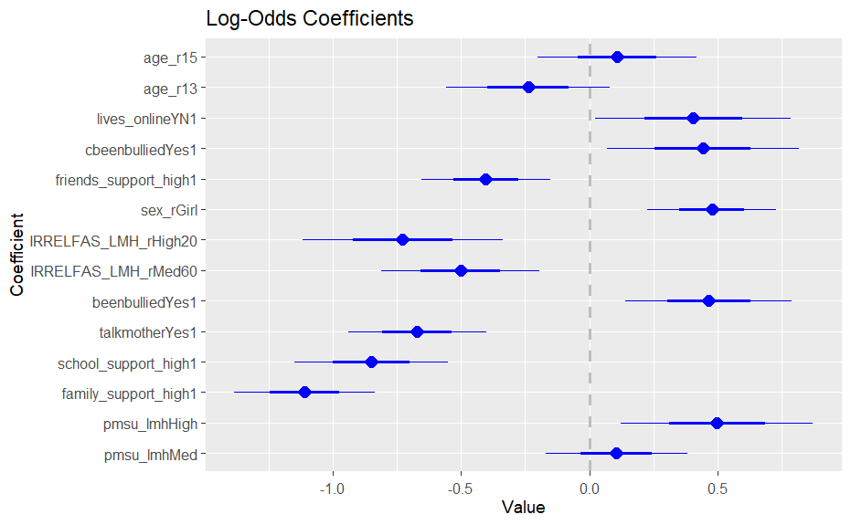

```r
coefplot(best, intercept = FALSE, title = "Log-Odds Coefficients")
```

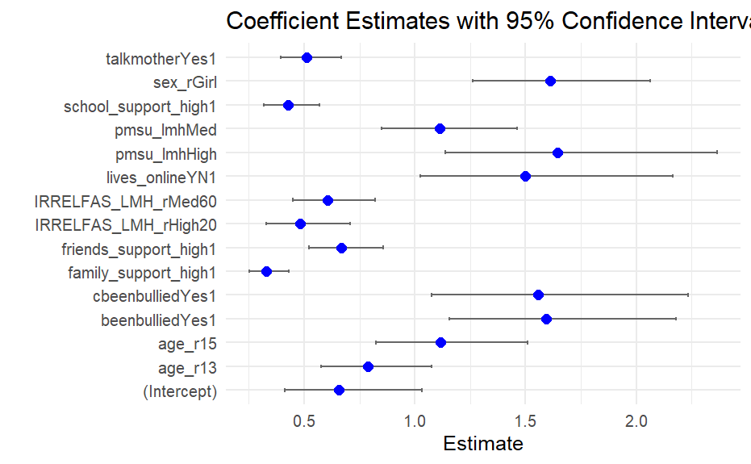

```r
mytidy <- tidy(best, exponentiate = TRUE, conf.int = TRUE)

ggplot(mytidy, aes(x = term, y = estimate)) +
  geom_errorbar(aes(ymin = conf.low, ymax = conf.high),
                width = 0.15, color = "gray40") +
  geom_point(size = 3, color = "blue") +
  coord_flip() +
  labs(
    title = "Coefficient Estimates with 95% Confidence Intervals",
    x = "",
    y = "Estimate"
  ) +
  theme_minimal(base_size = 14)
```

```r
NA
NA
NA
```

## For mental_complaintsY:

```r
# Fit GML model using forward subset selection
reg0 <- glm(mental_complaintsY ~ pmsu_lmh, data = italy, family = binomial)
reg1 <- glm(mental_complaintsY ~  pmsu_lmh +
              emconlfreqYes +
              lives_onlineYN +
              family_support_high +
              friends_support_high +
              school_support_high +
              IRRELFAS_LMH_r +
              talkfatherYes +
              talkmotherYes +
              beenbulliedYes +
              cbeenbulliedYes +
              timeexe_r +
              alc30d_YN +
              age_r +
              sex_r,
            data = italy,
            family = binomial)

summary(reg0)
```

```
Call:
glm(formula = mental_complaintsY ~ pmsu_lmh, family = binomial,
    data = italy)

Coefficients:
             Estimate Std. Error z value Pr(>|z|)
(Intercept)  -0.91110    0.06027  -15.12   <2e-16 ***
pmsu_lmhMed   0.88637    0.07813   11.34   <2e-16 ***
pmsu_lmhHigh  1.61283    0.12856   12.55   <2e-16 ***
---
Signif. codes:  0 ‘***’ 0.001 ‘**’ 0.01 ‘*’ 0.05 ‘.’ 0.1 ‘ ’ 1

(Dispersion parameter for binomial family taken to be 1)

    Null deviance: 4525.6  on 3313  degrees of freedom
Residual deviance: 4300.6  on 3311  degrees of freedom
AIC: 4306.6

Number of Fisher Scoring iterations: 4
```

```r
summary(reg1)
```

```
Call:
glm(formula = mental_complaintsY ~ pmsu_lmh + emconlfreqYes +
    lives_onlineYN + family_support_high + friends_support_high +
    school_support_high + IRRELFAS_LMH_r + talkfatherYes + talkmotherYes +
    beenbulliedYes + cbeenbulliedYes + timeexe_r + alc30d_YN +
    age_r + sex_r, family = binomial, data = italy)

Coefficients:
                      Estimate Std. Error z value Pr(>|z|)
(Intercept)           -0.17101    0.18253  -0.937 0.348819
pmsu_lmhMed            0.59355    0.08525   6.963 3.34e-12 ***
pmsu_lmhHigh           1.01642    0.14312   7.102 1.23e-12 ***
emconlfreqYes1         0.26907    0.08220   3.273 0.001063 **
lives_onlineYN1        0.59157    0.15874   3.727 0.000194 ***
family_support_high1  -0.42924    0.10734  -3.999 6.36e-05 ***
friends_support_high1 -0.32615    0.09074  -3.594 0.000325 ***
school_support_high1  -0.48271    0.08494  -5.683 1.32e-08 ***
IRRELFAS_LMH_rMed60   -0.07897    0.11223  -0.704 0.481643
IRRELFAS_LMH_rHigh20  -0.15901    0.13378  -1.189 0.234617
talkfatherYes1        -0.45170    0.08963  -5.039 4.67e-07 ***
talkmotherYes1        -0.28113    0.11000  -2.556 0.010596 *
beenbulliedYes1        0.29967    0.12697   2.360 0.018262 *
cbeenbulliedYes1       0.41203    0.15649   2.633 0.008465 **
timeexe_r1            -0.09258    0.08662  -1.069 0.285117
alc30d_YN1             0.37281    0.10067   3.703 0.000213 ***
age_r13                0.16463    0.09883   1.666 0.095742 .
age_r15                0.31667    0.11083   2.857 0.004274 **
sex_rGirl              0.68177    0.08345   8.170 3.08e-16 ***
---
Signif. codes:  0 ‘***’ 0.001 ‘**’ 0.01 ‘*’ 0.05 ‘.’ 0.1 ‘ ’ 1

(Dispersion parameter for binomial family taken to be 1)

    Null deviance: 4525.6  on 3313  degrees of freedom
Residual deviance: 3838.8  on 3295  degrees of freedom
AIC: 3876.8

Number of Fisher Scoring iterations: 3
```

```r
best <- step(reg0, scope = formula(reg1),
             direction = "forward", k = 2) #k=2 is AIC
```

```
Start:  AIC=4306.56
mental_complaintsY ~ pmsu_lmh

                       Df Deviance    AIC
+ talkfatherYes         1   4141.2 4149.2
+ family_support_high   1   4151.8 4159.8
+ school_support_high   1   4155.1 4163.1
+ talkmotherYes         1   4197.7 4205.7
+ sex_r                 1   4208.2 4216.2
+ age_r                 2   4230.3 4240.3
+ alc30d_YN             1   4257.0 4265.0
+ friends_support_high  1   4262.7 4270.7
+ cbeenbulliedYes       1   4270.7 4278.7
+ beenbulliedYes        1   4276.7 4284.7
+ lives_onlineYN        1   4278.6 4286.6
+ timeexe_r             1   4284.3 4292.3
+ emconlfreqYes         1   4286.5 4294.5
<none>                      4300.6 4306.6
+ IRRELFAS_LMH_r        2   4299.3 4309.3

Step:  AIC=4149.2
mental_complaintsY ~ pmsu_lmh + talkfatherYes

                       Df Deviance    AIC
+ school_support_high   1   4043.6 4053.6
+ family_support_high   1   4074.2 4084.2
+ sex_r                 1   4080.7 4090.7
+ age_r                 2   4101.2 4113.2
+ alc30d_YN             1   4107.1 4117.1
+ talkmotherYes         1   4108.3 4118.3
+ friends_support_high  1   4116.2 4126.2
+ cbeenbulliedYes       1   4118.8 4128.8
+ beenbulliedYes        1   4121.7 4131.7
+ lives_onlineYN        1   4122.4 4132.4
+ emconlfreqYes         1   4124.7 4134.7
+ timeexe_r             1   4130.1 4140.1
<none>                      4141.2 4149.2
+ IRRELFAS_LMH_r        2   4140.5 4152.5

Step:  AIC=4053.61
```

[output cut: 145 more lines]

```
+ beenbulliedYes  1   3841.8 3873.8
<none>                3847.2 3877.2
+ timeexe_r       1   3845.8 3877.8
+ IRRELFAS_LMH_r  2   3845.4 3879.4

Step:  AIC=3873.79
mental_complaintsY ~ pmsu_lmh + talkfatherYes + school_support_high +
    sex_r + family_support_high + alc30d_YN + lives_onlineYN +
    cbeenbulliedYes + friends_support_high + emconlfreqYes +
    talkmotherYes + age_r + beenbulliedYes

                 Df Deviance    AIC
<none>                3841.8 3873.8
+ timeexe_r       1   3840.2 3874.2
+ IRRELFAS_LMH_r  2   3839.9 3875.9
```

```r
summary(best)
```

```
Call:
glm(formula = mental_complaintsY ~ pmsu_lmh + talkfatherYes +
    school_support_high + sex_r + family_support_high + alc30d_YN +
    lives_onlineYN + cbeenbulliedYes + friends_support_high +
    emconlfreqYes + talkmotherYes + age_r + beenbulliedYes, family = binomial,
    data = italy)

Coefficients:
                      Estimate Std. Error z value Pr(>|z|)
(Intercept)           -0.31417    0.15045  -2.088 0.036775 *
pmsu_lmhMed            0.59562    0.08518   6.992 2.71e-12 ***
pmsu_lmhHigh           1.02064    0.14299   7.138 9.49e-13 ***
talkfatherYes1        -0.45346    0.08957  -5.063 4.13e-07 ***
school_support_high1  -0.48467    0.08480  -5.716 1.09e-08 ***
sex_rGirl              0.69186    0.08250   8.386  < 2e-16 ***
family_support_high1  -0.43886    0.10720  -4.094 4.24e-05 ***
alc30d_YN1             0.35944    0.10029   3.584 0.000338 ***
lives_onlineYN1        0.59184    0.15874   3.728 0.000193 ***
cbeenbulliedYes1       0.40256    0.15617   2.578 0.009948 **
friends_support_high1 -0.33622    0.09049  -3.716 0.000203 ***
emconlfreqYes1         0.26658    0.08215   3.245 0.001174 **
talkmotherYes1        -0.27468    0.10991  -2.499 0.012454 *
age_r13                0.16835    0.09857   1.708 0.087669 .
age_r15                0.32865    0.11038   2.977 0.002906 **
beenbulliedYes1        0.29635    0.12700   2.333 0.019625 *
---
Signif. codes:  0 ‘***’ 0.001 ‘**’ 0.01 ‘*’ 0.05 ‘.’ 0.1 ‘ ’ 1

(Dispersion parameter for binomial family taken to be 1)

    Null deviance: 4525.6  on 3313  degrees of freedom
Residual deviance: 3841.8  on 3298  degrees of freedom
AIC: 3873.8

Number of Fisher Scoring iterations: 3
```

```r
best$anova
```

| Step | Df | Deviance | Resid. Df | Resid. Dev | AIC |
| --- | --- | --- | --- | --- | --- |
|  | NA | NA | 3311 | 4300.559 | 4306.559 |
| + talkfatherYes | -1 | 159.363701 | 3310 | 4141.196 | 4149.196 |
| + school_support_high | -1 | 97.587358 | 3309 | 4043.608 | 4053.608 |
| + sex_r | -1 | 61.053684 | 3308 | 3982.555 | 3994.555 |
| + family_support_high | -1 | 41.346462 | 3307 | 3941.208 | 3955.208 |
| + alc30d_YN | -1 | 24.269173 | 3306 | 3916.939 | 3932.939 |
| + lives_onlineYN | -1 | 18.975497 | 3305 | 3897.963 | 3915.963 |
| + cbeenbulliedYes | -1 | 13.155088 | 3304 | 3884.808 | 3904.808 |
| + friends_support_high | -1 | 10.860180 | 3303 | 3873.948 | 3895.948 |
| + emconlfreqYes | -1 | 11.996150 | 3302 | 3861.952 | 3885.952 |

[output cut: 3 more lines]

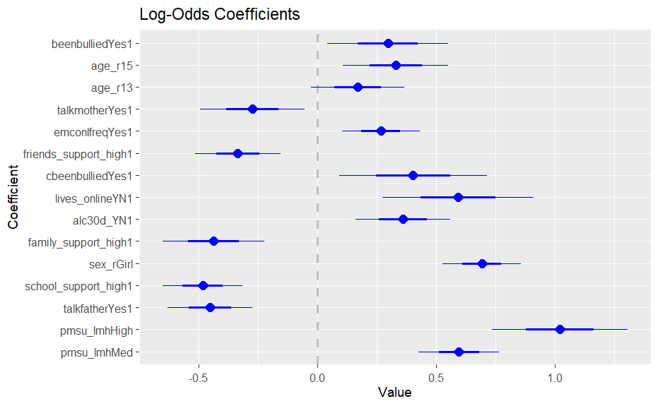

```r
coefplot(best, intercept = FALSE, title = "Log-Odds Coefficients")
```

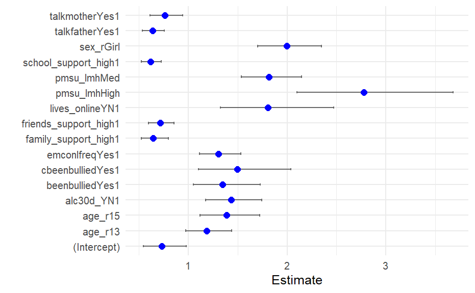

```r
mytidy <- tidy(best, exponentiate = TRUE, conf.int = TRUE)
ggplot(mytidy, aes(x = term, y = estimate)) +
  geom_errorbar(aes(ymin = conf.low, ymax = conf.high),
                width = 0.15, color = "gray40") +
  geom_point(size = 3, color = "blue") +
  coord_flip() +
  labs(
    #title = "Coefficient Estimates with 95% Confidence Intervals",
    x = "",
    y = "Estimate"
  ) +
  theme_minimal(base_size = 14)
```

```r
NA
NA
NA
```

## The first SHAP

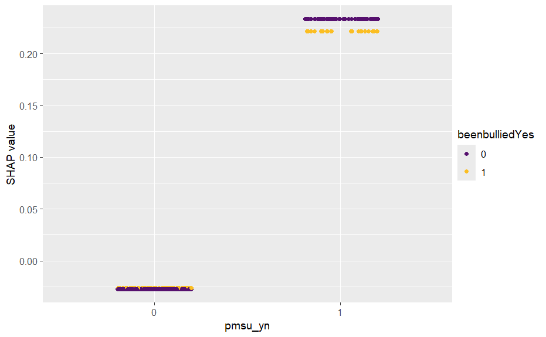

chi2 test hacer

https://www.r-bloggers.com/2023/09/decisions-at-the-door-understanding-logistic-regression-with-tidymodels/ https://www.tidymodels.org/ https://www.tmwr.org/ https://medium.com/data-science/shap-for-binary-and-multiclass-target-variables-ff2f43de0cf4 https://benhay.es/posts/interpreting-ml-shap/